# Example analysis

Author

GB

In this example analysis we estimate associations between different characteristics of persons and travel and car usage.

The goal is to give a short overview about the major building blocks of a Bayesian work flow (selection of priors, prior predictive check, posterior predictive check, model expansion) and to show how a Bayesian analysis can be described and reported.

We load packages.

```r
library(data.table)  # Provides fast data manipulation and aggregation functions.
library(magrittr)    # For the forward-pipe operator (%>%) for chaining commands.
library(skimr)       # Simplifies summary statistics generation for data frames.
library(brms)        # Facilitates Bayesian regression modeling using Stan.
library(brmsmargins) # Computes marginal effects for brms models.
library(posterior)   # Tools for working with posterior distributions.
library(bayesplot)   # Plotting functions for posterior distributions.
library(ggdist)      # Visualizations for distributions and uncertainty intervals.
library(ggplot2)     # Plotting figures based on the Grammar of Graphics.
library(patchwork)   # Combines multiple ggplot2 plots into a single layout.
library(knitr)       # Dynamic report generation in R.
library(glue)        # String interpolation for data in R.

options(mc.cores = 4)
source("utils.R")
```

## Load data

It is typically neccesarry to make some data manipulations.

```r
# Read data from a CSV file into a data.table
dt = fread("reisefil_slim.csv")


dt %>%
  # Remove specified columns and columns with more than 25% missing values
  .[, c("monthyear", "alderskategori", "V1", "NR", names(which(colMeans(is.na(dt)) > .25))) := NULL] %>%
  # Rename "car_driver_boo" column to "y"
  setnames("car_driver_boo", "y") %>%
  # Convert "dato" to Date type
  .[, dato := as.Date(dato)] %>%
  # Extract the month from the "dato" column and create a new column "month"
  .[, month := month(dato)] %>%
  # Extract the day of the year from "dato" and create a new column "yday"
  .[, yday := yday(dato)] %>%
  # Remove specific substrings from the "formaal" column
  .[, formaal := gsub(" / temporary accomodation", "", formaal)]

# Remove rows where "fylke" is NA
dt = dt[!is.na(fylke)]

# Identify character columns and ID column, convert them to factors
f_vars = sapply(dt, function(x) is.character(x)) %>% which() %>% names()
f_vars = c("ID", f_vars)
for (v in f_vars) dt[, (v) := factor(get(v))]

# Rename "day" column to "wday"
setnames(dt, c("day"), c("wday"))

# Set levels for the "wday" factor
levels(dt$wday) = c("Mon", "Tue", "Wed", "Thu", "Fri", "Sat", "Sun")

# Ensure specific levels are first in "formaal" and "yrke" factors
fm_lvls = c("To/from workplace", setdiff(levels(dt$formaal), "To/from workplace"))
yrk_lvls = c("Full-time", setdiff(levels(dt$yrke), "Full-time"))
dt[, formaal := factor(formaal, levels = fm_lvls)]
dt[, yrke := factor(yrke, levels = yrk_lvls)]

# Summarize the data.table
skim(dt)
```

Data summary

| Name | dt |
| --- | --- |
| Number of rows | 7324 |
| Number of columns | 25 |
| Key | NULL |
| _______________________ |  |
| Column type frequency: |  |
| Date | 1 |
| factor | 14 |
| numeric | 10 |
| ________________________ |  |
| Group variables | None |

**Variable type: Date**

| skim_variable | n_missing | complete_rate | min | max | median | n_unique |
| --- | --- | --- | --- | --- | --- | --- |
| dato | 0 | 1 | 2020-04-03 | 2021-10-31 | 2020-11-02 | 244 |

**Variable type: factor**

| skim_variable | n_missing | complete_rate | ordered | n_unique | top_counts |
| --- | --- | --- | --- | --- | --- |
| formaal | 0 | 1 | FALSE | 8 | Sho: 2031, Fre: 1896, To/: 1420, Sch: 749 |
| reisemiddel | 0 | 1 | FALSE | 7 | Car: 2734, By : 1854, Pub: 1125, Ped: 794 |
| ind | 0 | 1 | FALSE | 31 | del: 2325, hje: 1301, del: 916, del: 667 |
| student | 0 | 1 | FALSE | 2 | Not: 4844, Stu: 2480 |
| yrke | 0 | 1 | FALSE | 8 | Ful: 3978, Stu: 2480, Par: 322, Pen: 210 |
| kjoenn | 0 | 1 | FALSE | 3 | Fem: 5087, Mal: 2224, The: 13 |
| husholdning | 0 | 1 | FALSE | 5 | Sev: 2310, Cou: 2193, Cou: 1623, Sin: 981 |
| Kommunenavn | 0 | 1 | FALSE | 153 | TRO: 4642, OSL: 225, BOD: 216, STA: 203 |
| fylke | 0 | 1 | FALSE | 11 | TRO: 5129, MOE: 617, NOR: 570, INN: 389 |
| wday | 0 | 1 | FALSE | 7 | Tue: 1802, Fri: 1270, Sat: 1229, Thu: 1112 |
| hverdag | 0 | 1 | FALSE | 2 | Wee: 5898, Wee: 1426 |
| tellekategori | 0 | 1 | FALSE | 4 | 3-4: 3207, 5-6: 1890, 1-2: 1783, 7+ : 444 |
| tidskategori | 12 | 1 | FALSE | 7 | 15 : 1796, 5 -: 1643, < 5: 1460, 10 : 1351 |
| ID | 0 | 1 | FALSE | 2329 | 833: 10, 100: 10, 813: 9, 833: 9 |

**Variable type: numeric**

| skim_variable | n_missing | complete_rate | mean | sd | p0 | p25 | p50 | p75 | p100 | hist |
| --- | --- | --- | --- | --- | --- | --- | --- | --- | --- | --- |
| reisetid | 12 | 1 | 25.01 | 48.24 | 1 | 8 | 15 | 25 | 840 | ▇▁▁▁▁ |
| alder | 0 | 1 | 36.40 | 14.82 | 13 | 23 | 33 | 48 | 82 | ▇▅▅▃▁ |
| barn | 0 | 1 | 0.73 | 1.10 | 0 | 0 | 0 | 1 | 4 | ▇▂▂▁▁ |
| voksne | 0 | 1 | 2.49 | 1.12 | 0 | 2 | 2 | 3 | 7 | ▃▇▆▁▁ |
| totmedlem | 0 | 1 | 3.24 | 1.71 | 1 | 2 | 3 | 4 | 16 | ▇▂▁▁▁ |
| antall_reiser | 0 | 1 | 3.88 | 1.66 | 1 | 3 | 4 | 5 | 10 | ▅▇▅▁▁ |
| tottid | 0 | 1 | 85.63 | 104.17 | 2 | 36 | 59 | 95 | 1440 | ▇▁▁▁▁ |
| y | 0 | 1 | 0.37 | 0.48 | 0 | 0 | 0 | 1 | 1 | ▇▁▁▁▅ |
| month | 0 | 1 | 8.50 | 2.62 | 1 | 6 | 9 | 11 | 12 | ▁▁▅▂▇ |
| yday | 0 | 1 | 245.07 | 76.79 | 1 | 180 | 270 | 308 | 366 | ▁▁▅▂▇ |

## Simple model

We set up a simple model that respects basic characteristics of the data:

- repeated measurements of individuals
- clustering in fylke

To get the prior for the intercept that on average not more than 4/10 of individuals use public transport. Calculating `exp(.4)` gives approximately `1.5`

```r
# formula for the regression model
f = bf(y ~ (1 | ID) + (1 | fylke))

my_prior =
  prior(normal(0,1.5), class = "Intercept") + # prior for intercept
  prior(normal(0,2), class = "sd")            # prior for sd of hierarchical vars
```

### Prior predictive check

We generate predictions from the prior only

```r
# load_or_execute is a utility function that checks if the comuptations were
# already done. If yes, the saved results are loaded. If no, the compuations
# are done, the results save and returned.
load_or_execute("baseline_pp.Rdata",{
  pp_bl =
    brm(f,
        family = bernoulli(),
        data = dt,
        prior = my_prior,
        backend = "cmdstanr",
        iter = 1000,
        sample_prior = 'only')
})
```

```
Loaded objects from: baseline_pp.Rdata
```

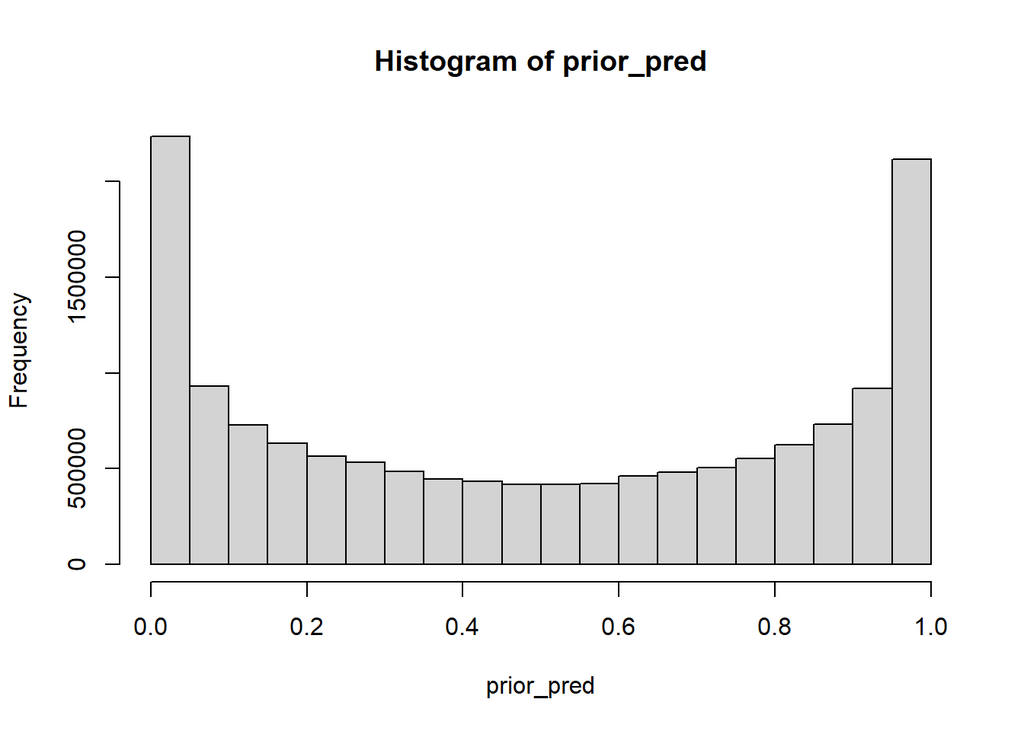

```r
# Convert linear predictions from the model-posterior [posterior_linpred(pp_bl)]
# to the probability scale using the inverse logit function
prior_pred = posterior_linpred(pp_bl) %>% boot::inv.logit()
hist(prior_pred)
```

The high probabilities of values near 0, 1 is due to the hieracical model

### Model estimation

```r
load_or_execute("baseline.Rdata", {
fit_bl =
    brm(f,
        family = bernoulli(),
        data = dt,
        prior = my_prior,
        backend = "cmdstanr",
        iter = 1000)
  save(fit_bl,file = fn)})
```

```
Loaded objects from: baseline.Rdata
```

### Convergence

```r
fit_bl %>% summary()
```

```
 Family: bernoulli
  Links: mu = logit
Formula: y ~ (1 | ID) + (1 | fylke)
   Data: dt (Number of observations: 7324)
  Draws: 4 chains, each with iter = 1000; warmup = 500; thin = 1;
         total post-warmup draws = 2000

Multilevel Hyperparameters:
~fylke (Number of levels: 11)
              Estimate Est.Error l-95% CI u-95% CI Rhat Bulk_ESS Tail_ESS
sd(Intercept)     3.01      0.67     1.93     4.45 1.00      719     1191

~ID (Number of levels: 2329)
              Estimate Est.Error l-95% CI u-95% CI Rhat Bulk_ESS Tail_ESS
sd(Intercept)     7.18      0.39     6.46     7.98 1.00      559      955

Regression Coefficients:
          Estimate Est.Error l-95% CI u-95% CI Rhat Bulk_ESS Tail_ESS
Intercept    -0.52      0.83    -2.17     1.13 1.00      690     1016

Draws were sampled using sample(hmc). For each parameter, Bulk_ESS
and Tail_ESS are effective sample size measures, and Rhat is the potential
scale reduction factor on split chains (at convergence, Rhat = 1).
```

We see that the main parameters of the model converged, and that there is substantial variation between fylke and individuals.

Here is a plot of all rhat values, i.e. also for all the random effects.

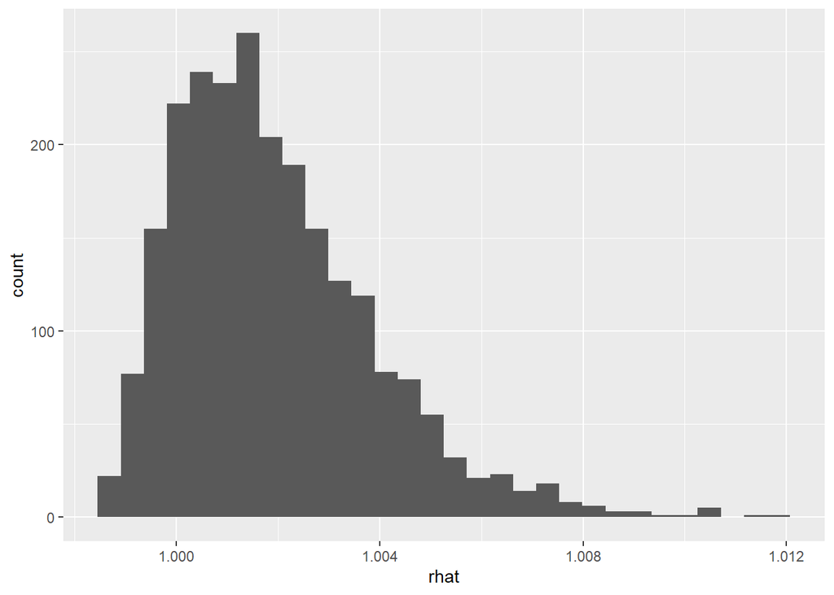

```r
s = fit_bl %>% as_draws() %>% summarise_draws()
s %>% ggplot(aes(x=rhat)) + geom_histogram(bins=30)
```

### Posterior predictive check

We check if the modeled propensity to take a car is consistent with the observed one[^1]

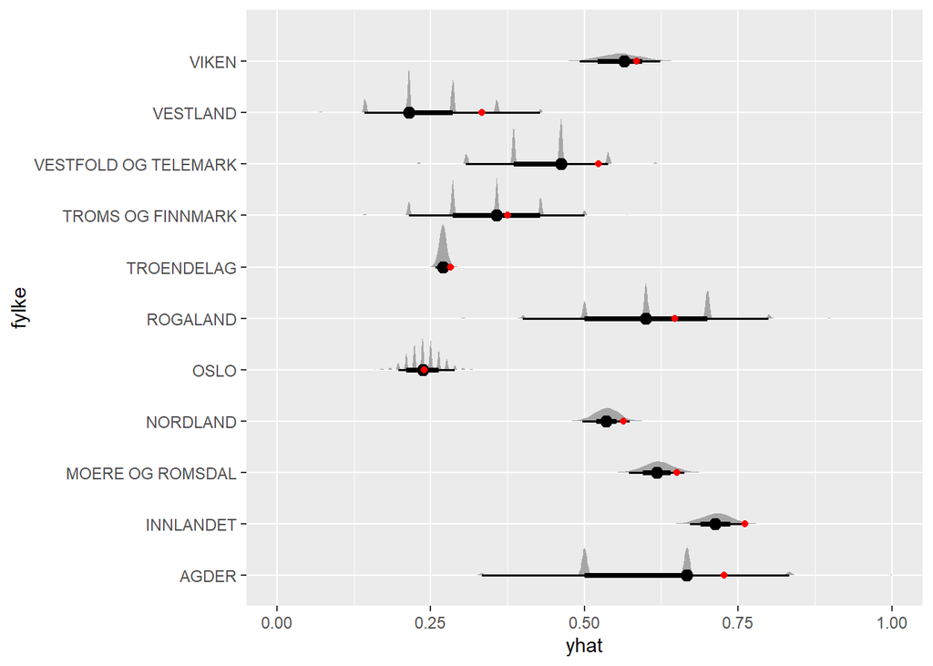

```r
obs = dt[, .(m = mean(y)), by = .(fylke)]

# Extract unique combinations of ID and fylke from the data table dt
new_data = unique(dt[, .(ID, fylke)])
# Generate posterior predictions from the brms model for the new data
pred = posterior_predict(fit_bl, newdata = new_data)
# Combine the new data with the transposed predictions and reshape into long format
pred = cbind(new_data, t(pred)) %>% melt(id.vars = names(new_data))
# Calculate the mean predicted value (yhat) for each fylke and variable combination
pred = pred[, .(yhat = mean(value)), by = .(fylke, variable)]


# plotting
pred %>%
  ggplot(aes(y = fylke, x = yhat)) +
  stat_slabinterval() +
  geom_point(data = obs, aes(x = m), col = "red") +
  xlim(0,1)
```

Posterior predictions are generally more variable and can therefor look a bit funny. We can get smoother prediction by using linear predictions and the link function. This omits the last step, generating a random response give the the response probabilities, from the generation of posterior predictions.

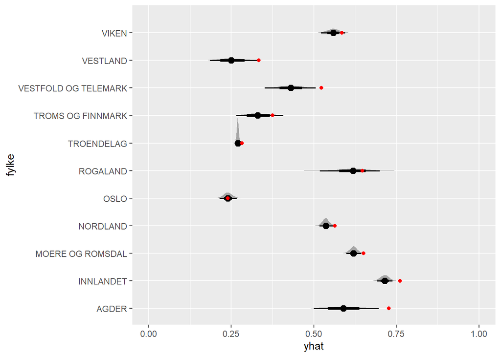

```r
obs = dt[, .(m = mean(y)), by = .(fylke)]

# Here we prepare and generate posterior predictions
pred = posterior_linpred(fit_bl, newdata = new_data) %>% boot::inv.logit()
pred = cbind(new_data,t(pred)) %>% melt(id.vars = names(new_data))
pred = pred[, .(yhat = mean(value)), by = .(fylke,variable)]

# plotting
pred %>%
  ggplot(aes(y = fylke, x = yhat)) +
  stat_slabinterval() +
  geom_point(data = obs, aes(x = m), col = "red") +
  xlim(0,1)
```

## Extending the model

We are adding some variables of interest:

- **formaal** is added as a fixed effect, as it has only few levels
- **yrke** is added as a fixed effect, as it has only few levels
- **kommune** is added as a random effect, as it has many levels and is nested in fylke

Note that we do not immediately fit the model with all variables of interest. We start on purpose with a simple model and add feature step for step. This allows us to pinpoint problems with a model much faster as compared to when we would start wit a big model.

We also widen the priors for the random effects, as the estimated priors were large compared to the sd of the prior.

Here are the new model formula and updated priors:

```r
f = bf(y ~ formaal + yrke + (1 | ID) + (1 | fylke + Kommunenavn))

my_prior =
  prior(normal(0,1), class = "Intercept") + # prior for intercept
  prior(normal(0,2), class = "b") +         # prior for fix effects
  prior(normal(0,3), class = "sd")          # prior for sd of hierarchical vars
```

We fit the model:

```r
load_or_execute("extend1.Rdata",{
  fit_e1 =
    brm(f,
        family = bernoulli(),
        data = dt,
        prior = my_prior,
        backend = "cmdstanr",
        iter = 1000)
  save(fit_e1,file = fn)
})
```

```
Loaded objects from: extend1.Rdata
```

```r
fit_e1 %>% summary()
```

```
 Family: bernoulli
  Links: mu = logit
Formula: y ~ formaal + yrke + (1 | ID) + (1 | fylke + Kommunenavn)
   Data: dt (Number of observations: 7324)
  Draws: 4 chains, each with iter = 1000; warmup = 500; thin = 1;
         total post-warmup draws = 2000

Multilevel Hyperparameters:
~fylke (Number of levels: 11)
              Estimate Est.Error l-95% CI u-95% CI Rhat Bulk_ESS Tail_ESS
sd(Intercept)     1.36      0.89     0.09     3.32 1.03      286      834

~ID (Number of levels: 2329)
              Estimate Est.Error l-95% CI u-95% CI Rhat Bulk_ESS Tail_ESS
sd(Intercept)     6.11      0.34     5.48     6.80 1.01      489      843

~Kommunenavn (Number of levels: 153)
              Estimate Est.Error l-95% CI u-95% CI Rhat Bulk_ESS Tail_ESS
sd(Intercept)     2.66      0.49     1.81     3.70 1.01      376      797

Regression Coefficients:
                                Estimate Est.Error l-95% CI u-95% CI Rhat
Intercept                           2.00      0.61     0.78     3.15 1.00
formaalBusinesstrip                 0.10      0.55    -1.03     1.17 1.00
formaalFreetimeactivities           0.07      0.21    -0.36     0.45 1.00
formaalOther                        1.15      0.41     0.36     1.96 1.00
formaalPickupDdropofftrip           2.52      0.31     1.94     3.13 1.00
formaalSchoolDuniversity           -2.90      0.55    -4.03    -1.86 1.00
formaalShoppingDgroceryDservice     1.26      0.19     0.88     1.64 1.00
formaalUndirectedroundtrips        -5.04      0.60    -6.20    -3.89 1.00
yrkeCareworkunemployment           -0.44      1.21    -2.82     2.00 1.00
yrkeGotoschool                     -5.94      1.23    -8.42    -3.58 1.00
yrkeOther                          -1.24      1.29    -3.85     1.26 1.00
yrkeParentalleave                  -1.78      1.56    -4.88     1.22 1.00
yrkePartMtime                      -0.13      0.71    -1.50     1.23 1.00
yrkePensioner                       1.21      0.92    -0.54     3.03 1.00
yrkeStudenthighereducation         -6.15      0.50    -7.15    -5.20 1.02
                                Bulk_ESS Tail_ESS
Intercept                            939     1243
formaalBusinesstrip                 1409     1688
formaalFreetimeactivities           1296     1544
formaalOther                        1765     1597
formaalPickupDdropofftrip           1651     1357
formaalSchoolDuniversity            1542     1585
formaalShoppingDgroceryDservice     1413     1318
formaalUndirectedroundtrips         1317     1382
yrkeCareworkunemployment             941     1118
yrkeGotoschool                      1242     1445
yrkeOther                            944     1187
yrkeParentalleave                   1595     1546
yrkePartMtime                        564     1052
yrkePensioner                        366      767
yrkeStudenthighereducation           463      934

Draws were sampled using sample(hmc). For each parameter, Bulk_ESS
and Tail_ESS are effective sample size measures, and Rhat is the potential
scale reduction factor on split chains (at convergence, Rhat = 1).
```

### “Effect” calcuations

We put “effect” in parenthesis, because this are not causal effects but simple associations.

The model converged, but it is a bit hard to understand the coefficients, so we use the `brmsmargins` package to calculate results on the scale of *risk differences*:

When using `brmsmargins` it is useful to have a function that generates pairwise contrasts.

```r
# Define a function to create pairwise contrasts
pairwise_contrasts = function(levels) {
  # Generate all unique pairs of the given levels
  pairs <- t(combn(levels, 2))

  # Initialize the contrast matrix with zeros
  # The number of rows is equal to the number of pairs
  # The number of columns is equal to the number of levels
  contrast_matrix <- matrix(0, nrow = nrow(pairs), ncol = length(levels))

  # Assign column names to the contrast matrix using the provided levels
  colnames(contrast_matrix) <- levels

  # Fill in the contrast matrix
  for (i in 1:nrow(pairs)) {
    # Set the element corresponding to the first level of the pair to 1
    contrast_matrix[i, pairs[i, 1]] <- 1
    # Set the element corresponding to the second level of the pair to -1
    contrast_matrix[i, pairs[i, 2]] <- -1
  }

  # Assign row names to the contrast matrix to indicate which levels are being compared
  rownames(contrast_matrix) = paste0(pairs[, 1], "-", pairs[, 2])

  # Return the completed contrast matrix
  return(contrast_matrix)
}
```

Here we use brms margins to calculate

1. The probability of car use by formaal group
2. All pairwise differences, the latter using the function we just generated

Note that it is important to appropriately use random effects when calculating fixed effects.

```r
load_or_execute("ame/ame_formaal.Rdata", {
  ame_formaal =
    brmsmargins(
      fit_e1,
      ### points at which to make predictions ###
      at = data.frame(formaal = fm_lvls),
      ### comparisons of groups ###
      contrasts = pairwise_contrasts(fm_lvls) %>% t(),
      ### width of credible interval in % of posterior ###
      CI = .9,
      ### correct treatment of random effects ###
      effects = "integrateoutRE"
    )})
```

```
Loaded objects from: ame/ame_formaal.Rdata
```

```r
ame_formaal$Summary = cbind(ame_formaal$Summary, Label = fm_lvls)
colnames(ame_formaal$Posterior) = fm_lvls
```

We can plot the results with 50% and 90% credible intervals.

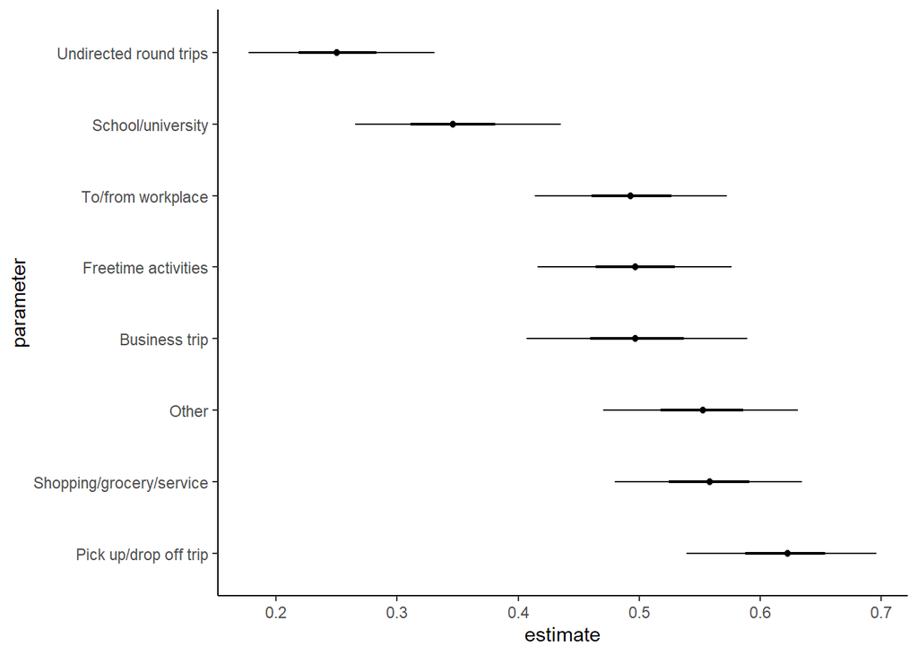

Estimated probability of car use for different formaal with 50% and 90% CIs.

```r
# mcmc_intervals_sorted is a custom utility function
ame_formaal$Posterior %>% mcmc_intervals_sorted()
```

We can plot the posterior distribution.

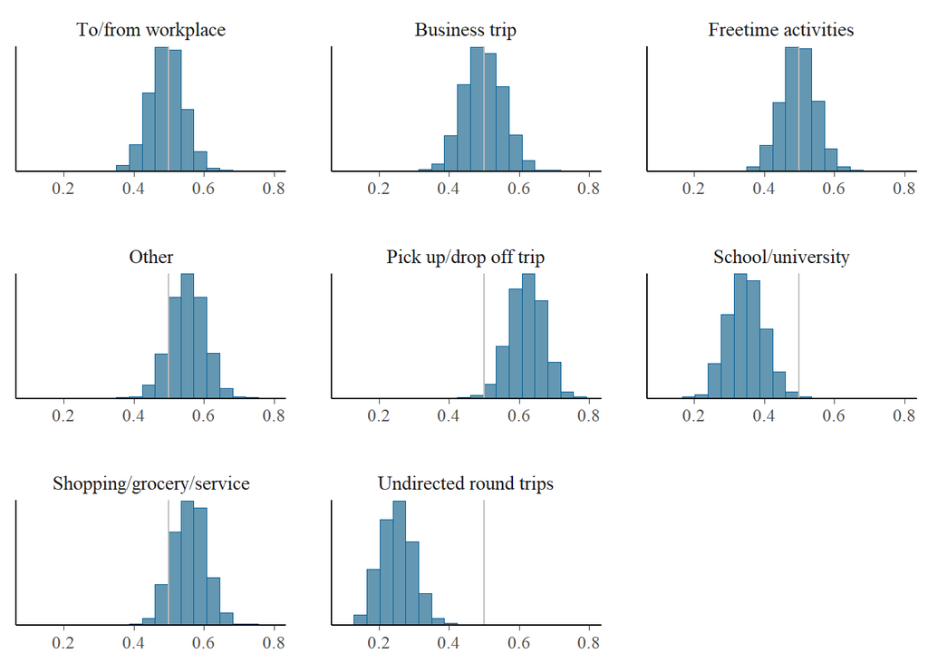

Posterior distribution of the estimated probability of car use for different formaal

```r
ame_formaal$Posterior %>% mcmc_hist(bins = 20) +
  xlim(.1, .8) + geom_vline(xintercept = .5, color = "grey")
```

And we can plot the table with the main results:

```r
ame_formaal$Posterior %>%
  summarise_draws() %>% .[, c("variable","mean","sd","q5","q95")] %>%
  kable(caption = "Probability to use a car by formaal", digits = c(2,3,2,2))
```

Probability to use a car by formaal

| variable | mean | sd | q5 | q95 |
| --- | --- | --- | --- | --- |
| To/from workplace | 0.493 | 0.05 | 0.41 | 0.57 |
| Business trip | 0.498 | 0.05 | 0.41 | 0.59 |
| Freetime activities | 0.497 | 0.05 | 0.42 | 0.58 |
| Other | 0.552 | 0.05 | 0.47 | 0.63 |
| Pick up/drop off trip | 0.621 | 0.05 | 0.54 | 0.70 |
| School/university | 0.347 | 0.05 | 0.27 | 0.44 |
| Shopping/grocery/service | 0.558 | 0.05 | 0.48 | 0.63 |
| Undirected round trips | 0.251 | 0.05 | 0.18 | 0.33 |

Finally, we can plot the differences between formaal.

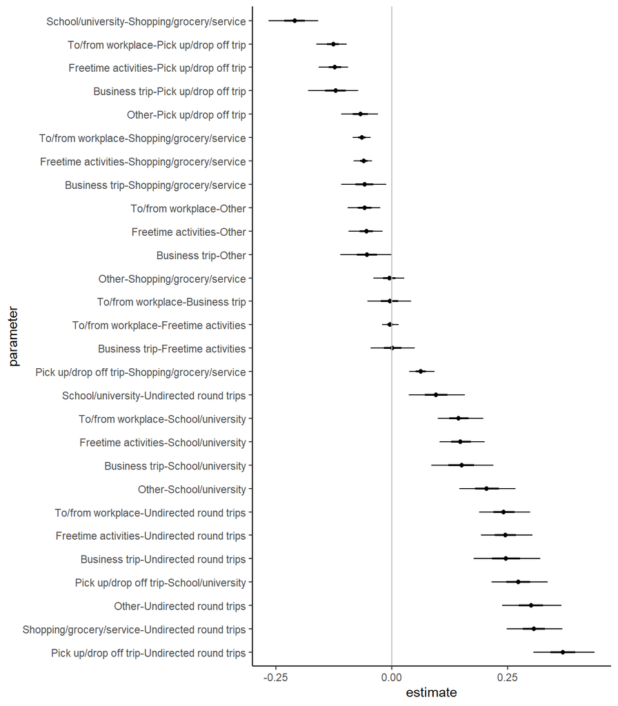

Estimated difference in probability of car use between all formaal

```r
ame_formaal$Contrasts %>% mcmc_intervals_sorted() + geom_hline(yintercept = 0, color = "grey")
```

And we can also look at the variation between kommune:

```r
kommuner = dt[, .(m = mean(y)), by = "Kommunenavn"][order(-m)][,Kommunenavn]
load_or_execute("ame/ame_kommuner.Rdata",{
  ame_kommune =
    brmsmargins(
      fit_e1,
      at = data.frame(Kommunenavn = kommuner),
      effects = "includeRE",
      CI = .9)})
```

```
Loaded objects from: ame/ame_kommuner.Rdata
```

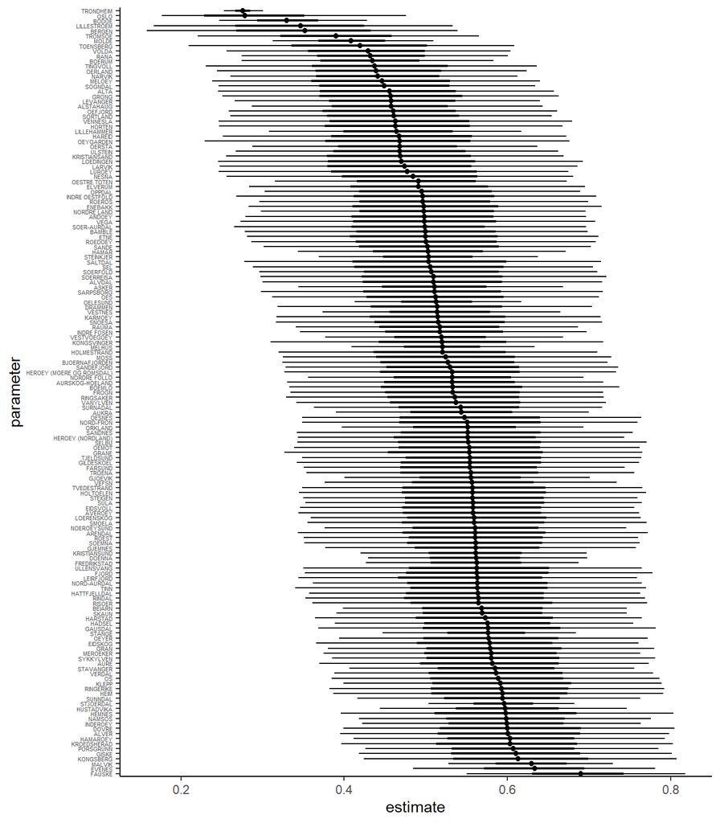

Estimated probability of car use for all kommuner

```r
colnames(ame_kommune$Posterior) = kommuner
ame_kommune$Posterior  %>% mcmc_intervals_sorted() +
  theme(axis.text.y = element_text(size = 4))
```

We see that there is a clear difference between kommuner, but to see more clearly, we can zoom in on the most extreme kommuner.

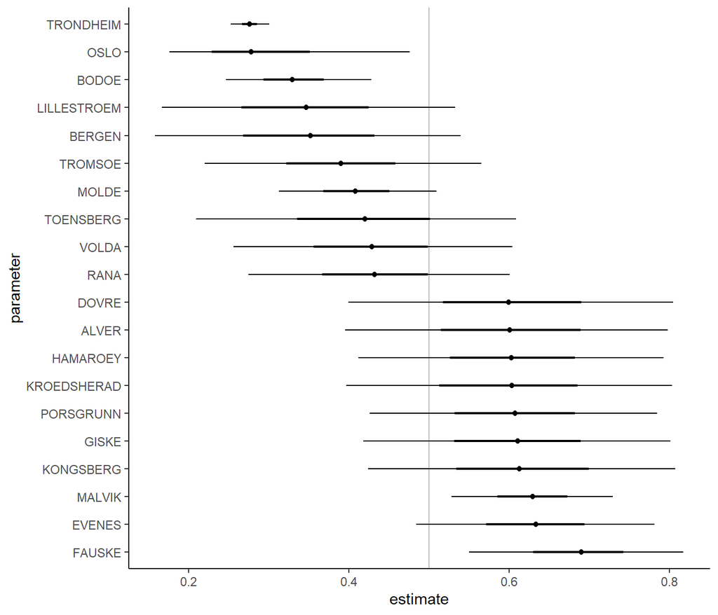

Estimated probability of car use in extreme kommuner

```r
pdata = ame_kommune$Posterior %>% mcmc_intervals_data()
pdata$parameter = factor(pdata$parameter, levels = pdata$parameter[order(-pdata$m)])

extreme_kommune = c(
  pdata$parameter %>% levels() %>% head(10),
  pdata$parameter %>% levels() %>% tail(10)
)

pdata %>%
  data.table() %>%
  .[parameter %in% extreme_kommune] %>%
  ggplot(aes(x = parameter, y = m)) +
  geom_hline(yintercept = .5, color = "grey") +
  geom_linerange(aes(ymin = ll, ymax = hh)) +
  geom_linerange(aes(ymin = l, ymax = h), linewidth = .8) +
  geom_point() +
  coord_flip() +
  theme_classic() +
  ylab("estimate")
```

## Further extensions

After seeing that this basic model works, we add additional relevant variables. In particular

1. Gender
2. Day of the week (wday)
3. Day in the year (yday) to capture seasonal trends with cyclic splines
4. Date to capture time trends
5. Age
6. Traveling time

We use splines to estimate effects of continuous variables.

```r
dt[, ndate := as.numeric(dato)]
# Define the model formula using the brms package
f = bf(
  y ~
    formaal + yrke + kjoenn + wday +  # Fixed effects for categorical variables
    s(yday, bs = "cc") +              # Smoothing spline for day of the year with cyclic cubic basis
    s(alder, k = 5) +                 # Smoothing spline for age with 5 knots
    s(reisetid, k = 5) +              # Smoothing spline for travel time with 5 knots
    s(ndate) +                        # Smoothing spline for date (number of days from a reference point)
    (1 | ID) +                        # Random intercept for individuals
    (1 | fylke/Kommunenavn)           # Nested random intercepts for fylke (region) and Kommunenavn (municipality)
)

my_prior =
  prior(normal(0,1), class = "Intercept") + # prior for intercept
  prior(normal(0,2), class = "b") +         # prior for fix effects
  prior(normal(0,3), class = "sds") +       # prior for splines
  prior(normal(0,3), class = "sd")          # prior for sd of hierarchical vars

load_or_execute("extend2.Rdata",{
  fit_e2 =
    brm(f,
        family = bernoulli(),
        data = dt,
        prior = my_prior,
        backend = "cmdstanr",
        iter = 1000)
})
```

```
Loaded objects from: extend2.Rdata
```

```r
fit_e2 %>% summary()
```

[output not shown]

[output cut: 31 more lines]

```
kjoennMale                           443      966
kjoennThem                          2033     1346
wdayTue                              434      741
wdayWed                              466      882
wdayThu                              357      814
wdayFri                              376      578
wdaySat                              370      594
wdaySun                              506      786
salder_1                            1482     1192
sreisetid_1                         2147     1475
sndate_1                             905     1176

Draws were sampled using sample(hmc). For each parameter, Bulk_ESS
and Tail_ESS are effective sample size measures, and Rhat is the potential
scale reduction factor on split chains (at convergence, Rhat = 1).
```

### Model description for ther methods section

> In this study, we estimated a Bayesian generalized linear mixed effects model using the brms package in R. The binary outcome variable y was modeled as a Bernoulli distribution. Fixed effects included categorical predictors (formaal, yrke, kjoenn, wday) and continuous predictors (alder, reisetid, yday, ndate).

> Smooth terms were included to capture non-linear relationships:

> A cyclic cubic spline was used to account for potential seasonality in the data. Thin plate regression splines were employed to model non-linear associations with age, travel time, and date. Additionally, random intercepts for ID and nested random intercepts for county and municipality were incorporated to account for hierarchical structure in the data. Weakly informative priors were specified as follows: Intercept: Normal(0, 1); Fixed effects: Normal(0, 2); Standard deviations of splines: Normal(0, 3); Standard deviation of group-level effects: Normal(0, 3).

> The model was fit using the cmdstanr backend with 4 chains à 1000 iterations, whereby the first 500 warmup-draws from each chain were discarded.

### Results: Convergence

Here is a possible description of the model for a methods section:

The model was fit using the Hamiltonian Monte Carlo (HMC) algorithm with 4 chains, each with 1000 iterations (500 warmup and 500 post-warmup iterations), resulting in a total of 2000 post-warmup draws. The convergence diagnostics indicate that the model has generally converged well. Most parameters have an Rhat value close to 1, suggesting good mixing and convergence of the chains. The effective sample size (Bulk_ESS and Tail_ESS) is adequate for most parameters, indicating sufficient sampling efficiency.

There were 5 divergent transitions after the warmup phase. Despite these divergences, the overall convergence metrics suggest that the majority of parameters were estimated reliably.

The smoothing spline hyperparameters and multilevel effects for the grouping factors (`fylke`, `ID`, and `Kommunenavn`) also show appropriate Rhat values and effective sample sizes, further supporting the model’s convergence.

### Results: Content

First lets look at the effect of gender:

```r
load_or_execute("ame/ame_kjoenn2.Rdata",{
ame_kjoenn =
  brmsmargins(
    fit_e2,
    at = data.frame(kjoenn = levels(dt$kjoenn)),
    contrasts = pairwise_contrasts(levels(dt$kjoenn)) %>% t(),
    effects = "integrateoutRE",
    CI = .9)})
```

```
Loaded objects from: ame/ame_kjoenn2.Rdata
```

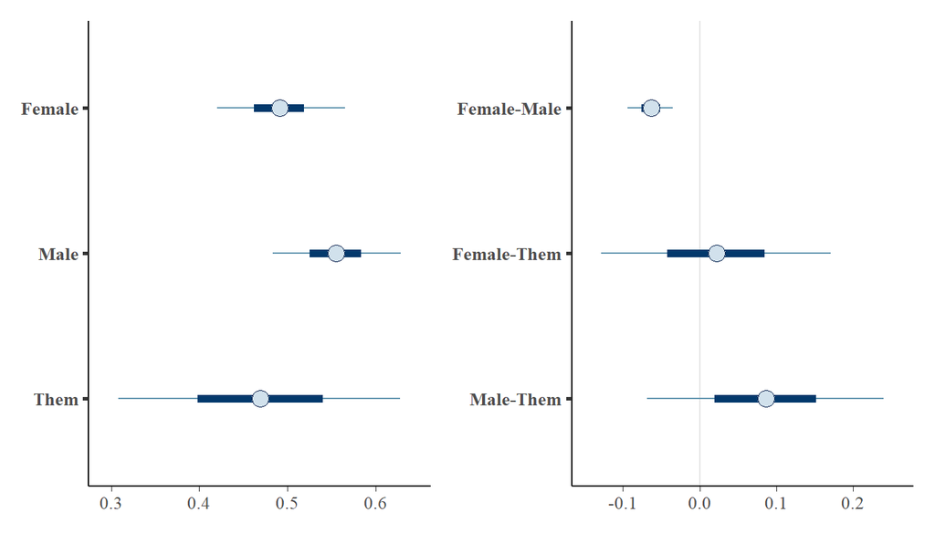

Associations between gender and car usage

```r
colnames(ame_kjoenn$Posterior) = levels(dt$kjoenn)
ame_kjoenn$Posterior %>% as_draws() %>% mcmc_intervals() +
ame_kjoenn$Contrasts %>% as_draws() %>% mcmc_intervals()
```

### Main results in the result section.

#### Written by GB:

> The adjusted probability to use a car is 0.49 (0.42, 0.57) among women, 0.55 (0.48, 0.63) among men. The difference between women and men is -0.06 (-0.09, -0.04) and is reliable different from zero.

#### ChatGPT 4o

**ChatGPT prompt:**

> briefly describe the results in these table, which describe fixed effects of gender on the probability to use a car. Describe the results as is typically done in scientific articles. use 2 decimal points.

> Table 1: Gender mean median sd mad q5 q95 rhat ess_bulk ess_tail Female 0.491 0.491 0.0437 0.0422 0.420 0.566 1.00 519. 1108. Male 0.555 0.555 0.0448 0.0439 0.483 0.629 1.00 610. 1079. Them 0.469 0.469 0.0994 0.106 0.308 0.628 1.00 1533. 1502.

> Table2: GenderDiffernence mean median sd mad q5 q95 rhat ess_bulk ess_tail Female-Male -0.0637 -0.0631 0.0180 0.0177 -0.0940 -0.0351 1.00 430. 959. Female-Them 0.0216 0.0223 0.0913 0.0933 -0.128 0.171 1.00 1997. 1353. Male-Them 0.0853 0.0859 0.0938 0.0976 -0.0684 0.240 1.00 1630. 1315.

**ChatGPT output:**

> The Rhat values are all 1.00, indicating good convergence, and the effective sample sizes are adequate, suggesting reliable estimates.

### Contrasts for nonlinear predictors

The advantage of non-linear predictors is that they do not require that we commit to a particular shape for the association between predictors and outcomes. The disadvantage is that it is less straight forward to generate contrasts. However, while this is next to impossible in the frequentist framework, we can do this relatively straiht forward in the Bayesian framework. Here we take seasonal changes in cart usage as in example.

#### Marginal car usage througout the year

First, we generate for different days in the year the expected car usage with the `brmsmargins` package. While our `yday` variable has 366 different value, we will restrict our-self to a subset of 52 days, one per week.

```r
days = seq(3,366, by = 7)
load_or_execute("ame/ame_yday.Rdata",{
  ame_yday =
    brmsmargins(
      fit_e2,
      at = data.frame(yday = days),
      effects = "integrateoutRE",
      CI = .9)})
```

```
Loaded objects from: ame/ame_yday.Rdata
```

```r
dim(ame_yday$Posterior)
```

```
[1] 2000   52
```

```r
head(ame_yday$Posterior,3)
```

```
          [,1]      [,2]      [,3]      [,4]      [,5]      [,6]      [,7]
[1,] 0.5496036 0.5492975 0.5475696 0.5452229 0.5430648 0.5419072 0.5425493
[2,] 0.6138757 0.6127878 0.6098286 0.6059759 0.6022113 0.5995214 0.5988772
[3,] 0.5272255 0.5351591 0.5445208 0.5541319 0.5628375 0.5695089 0.5730523
          [,8]      [,9]     [,10]     [,11]     [,12]     [,13]     [,14]
[1,] 0.5451740 0.5491243 0.5536853 0.5581500 0.5618215 0.5640117 0.5640666
[2,] 0.6004732 0.6034420 0.6068406 0.6097293 0.6111723 0.6102341 0.6060229
[3,] 0.5731128 0.5703269 0.5653892 0.5589928 0.5518385 0.5446393 0.5381065
         [,15]     [,16]     [,17]     [,18]     [,19]     [,20]     [,21]
[1,] 0.5621609 0.5593548 0.5567582 0.5554903 0.5566474 0.5604952 0.5663007
[2,] 0.5989191 0.5906727 0.5831160 0.5780945 0.5774166 0.5815609 0.5894007
[3,] 0.5325932 0.5280627 0.5244562 0.5217129 0.5197735 0.5186921 0.5186593
         [,22]     [,23]     [,24]     [,25]     [,26]     [,27]     [,28]
[1,] 0.5732728 0.5806328 0.5876226 0.5935072 0.5977608 0.6004358 0.6016832
[2,] 0.5997079 0.6112553 0.6228242 0.6332150 0.6415439 0.6478153 0.6521945
```

[output cut: 17 more lines]

Now we have 2000 samples for each of the 52 days. Lets plot this.

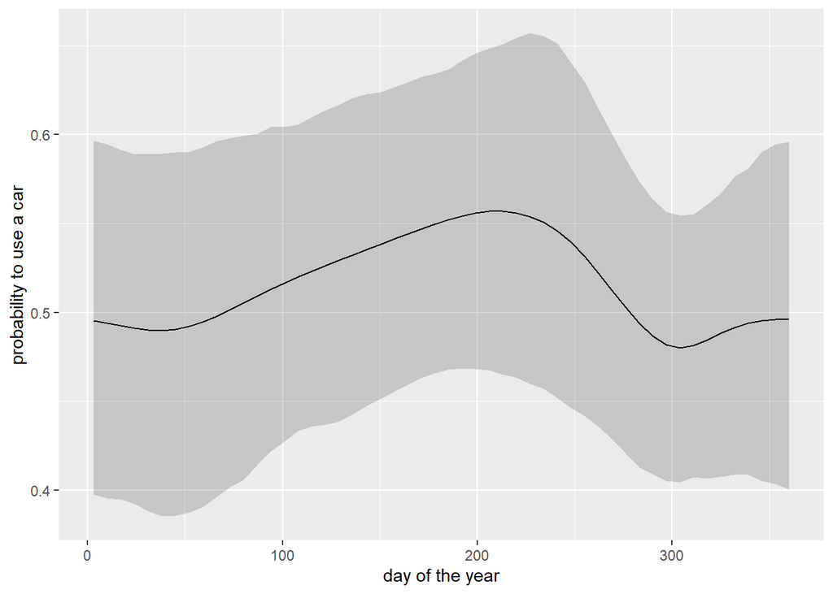

```r
colnames(ame_yday$Posterior) = days
ame_yday$Posterior %>%
  summarise_draws() %>%
  ggplot(aes(x = as.numeric(variable), y = mean)) +
  geom_line(alpha = .25, color = "blue3") +
  geom_ribbon(aes(ymin = q5, ymax = q95), alpha = .2) +
  geom_line() +
  ylab("probability to use a car") +
  xlab("day of the year")
```

A spaghetti plot can often give better insight into variability.

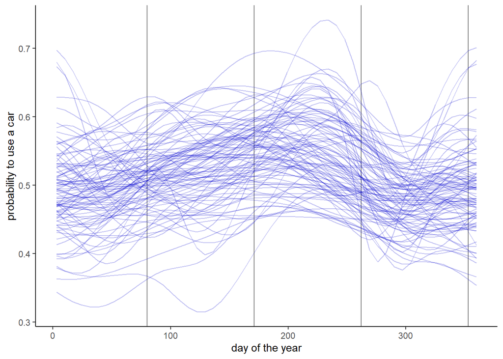

Spaghetti plot of seasonal changes in car use. Vertical lines indicate season starts.

```r
data.table(ame_yday$Posterior, iter = 1:2000) %>%
  melt(id.var = "iter", variable.name = "doy") %>%
  .[, doy := days[as.numeric(doy)]] %>%
  .[iter %in% sample(iter,100)] %>%
  ggplot(aes(x = doy, y = value, group = iter)) +
  geom_vline(xintercept = days[c(12,25,38,51)], alpha = .5) +
  geom_line(alpha = .25, color = "blue3") +
  theme_classic() +
  ylab("probability to use a car") +
  xlab("day of the year")
```

This plot suggests that the seasonal changes we observe are not reliable. Lets verify this statistically by checking.

To do this, we generate a contrast matrix with which we multiply the posterior distribution matrix of daily car usage to obtain the comparisons.

```r
# Create a matrix with 52 rows and 4 columns, initialized to 0
seasons = matrix(0, nrow = 52, ncol = 4)

# Assign column names to the matrix for the four seasons
colnames(seasons) = c("winter", "spring", "summer", "autumn")

# Define the weeks for each season
# Set weeks 1 to 12 and week 52 as winter (1-based indexing)
seasons[c(1:12, 52), 1] = 1
seasons[13:25, 2] = 1 # spring
seasons[26:38, 3] = 1  #summer
seasons[39:51, 4] = 1 # autumn

# Initialize an empty vector to store contrasts
my_contrasts = c()

# Generate all combinations of two seasons out of four
combs = combn(4, 2)

# Loop over each combination to calculate contrasts
for (i in 1:ncol(combs)) {
  # Calculate the contrast between two seasons
  my_contrasts = cbind(
    my_contrasts,
    seasons[, combs[1, i]] / sum(seasons[, combs[1, i]]) -
    seasons[, combs[2, i]] / sum(seasons[, combs[2, i]])
  )
}

# Assign column names to the contrast matrix to indicate the season comparisons
colnames(my_contrasts) = paste0(colnames(seasons)[combs[1,]], "-", colnames(seasons)[combs[2,]])
```

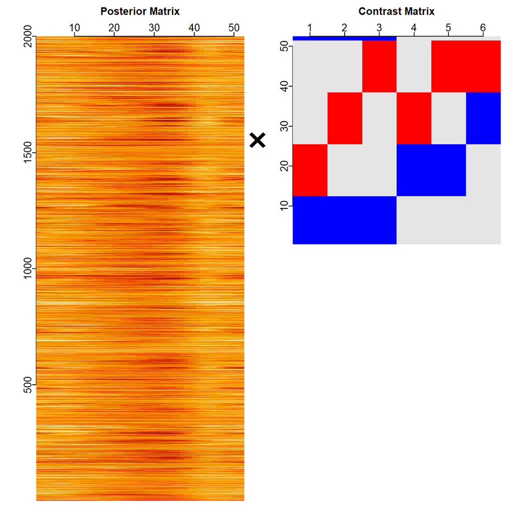

Visualisation of matrix multiplication to calculate contrasts.

```r
post_delta =  ame_yday$Posterior %*% my_contrasts
post_delta %>%
  summarise_draws() %>% .[, c("variable","mean","sd","q5","q95")]
```

```
# A tibble: 6 × 5
  variable          mean     sd       q5    q95
  <chr>            <dbl>  <dbl>    <dbl>  <dbl>
1 winter-spring -0.0342  0.0427 -0.108   0.0304
2 winter-summer -0.0534  0.0509 -0.142   0.0188
3 winter-autumn  0.00318 0.0342 -0.0524  0.0570
4 spring-summer -0.0192  0.0367 -0.0858  0.0320
5 spring-autumn  0.0374  0.0349 -0.0153  0.0975
6 summer-autumn  0.0566  0.0344  0.00422 0.119
```

```r
#%>%  kable(caption = "Seasonal differneces in probability to use a car", digits = c(2,3,2,2))
```

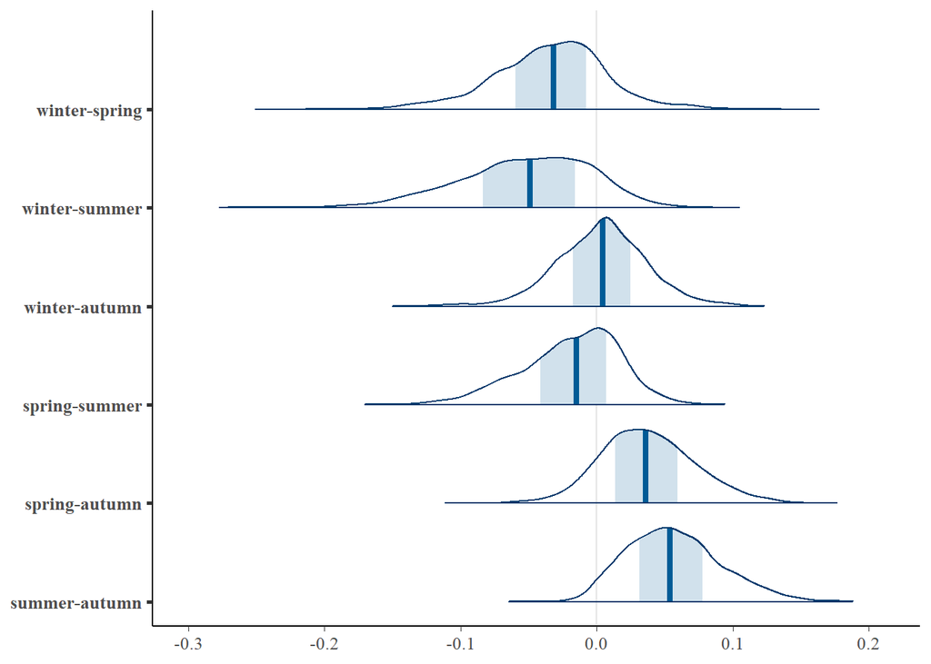

```r
post_delta %>% mcmc_areas()
```

The comparison between summer and autumn shows a credible interval that does not include zero, indicating a reliable difference. Specifically, the mean difference is 0.06 (CI: 0.004, 0.12). Other seasonal comparisons did not show credible intervals that exclude zero, suggesting no reliable differences in those cases.

## Prior sensitivity check

The goal of a prior sensitivity check is to verify that the results obtained do not depend on the specific priors chosen.

To assess sensitivity to priors, we estimate the model with different priors for fixed effects, random effects and spline coefficients.

```r
for (sdb in c(1,2,4,8)) {
  for (sdsds in c(1,3,6)) {
    for (sdsd in c(1,3,6)) {
      load_or_execute(glue("fits/extend2_{sdb}_{sdsds}_{sdsd}.Rdata"),{
        fit_e2 =
          brm(f,
              family = bernoulli(),
              data = dt,
              prior = my_prior,
              backend = "cmdstanr",
              iter = 1000)
      })
    }
  }
}
```

```
Loaded objects from: fits/extend2_1_1_1.Rdata
```

```
Loaded objects from: fits/extend2_1_1_3.Rdata
```

```
Loaded objects from: fits/extend2_1_1_6.Rdata
```

```
Loaded objects from: fits/extend2_1_3_1.Rdata
```

```
Loaded objects from: fits/extend2_1_3_3.Rdata
```

```
Loaded objects from: fits/extend2_1_3_6.Rdata
```

```
Loaded objects from: fits/extend2_1_6_1.Rdata
```

```
Loaded objects from: fits/extend2_1_6_3.Rdata
```

```
Loaded objects from: fits/extend2_1_6_6.Rdata
```

```
Loaded objects from: fits/extend2_2_1_1.Rdata
```

```
Loaded objects from: fits/extend2_2_1_3.Rdata
```

```
Loaded objects from: fits/extend2_2_1_6.Rdata
```

```
Loaded objects from: fits/extend2_2_3_1.Rdata
```

```
Loaded objects from: fits/extend2_2_3_3.Rdata
```

```
Loaded objects from: fits/extend2_2_3_6.Rdata
```

```
Loaded objects from: fits/extend2_2_6_1.Rdata
```

```
Loaded objects from: fits/extend2_2_6_3.Rdata
```

```
Loaded objects from: fits/extend2_2_6_6.Rdata
```

```
Loaded objects from: fits/extend2_4_1_1.Rdata
```

```
Loaded objects from: fits/extend2_4_1_3.Rdata
```

```
Loaded objects from: fits/extend2_4_1_6.Rdata
```

```
Loaded objects from: fits/extend2_4_3_1.Rdata
```

```
Loaded objects from: fits/extend2_4_3_3.Rdata
```

```
Loaded objects from: fits/extend2_4_3_6.Rdata
```

```
Loaded objects from: fits/extend2_4_6_1.Rdata
```

```
Loaded objects from: fits/extend2_4_6_3.Rdata
```

```
Loaded objects from: fits/extend2_4_6_6.Rdata
```

```
Loaded objects from: fits/extend2_8_1_1.Rdata
```

```
Loaded objects from: fits/extend2_8_1_3.Rdata
```

```
Loaded objects from: fits/extend2_8_1_6.Rdata
```

```
Loaded objects from: fits/extend2_8_3_1.Rdata
```

```
Loaded objects from: fits/extend2_8_3_3.Rdata
```

```
Loaded objects from: fits/extend2_8_3_6.Rdata
```

```
Loaded objects from: fits/extend2_8_6_1.Rdata
```

```
Loaded objects from: fits/extend2_8_6_3.Rdata
```

```
Loaded objects from: fits/extend2_8_6_6.Rdata
```

Next, we calculate, as an example, gender effects for all prior specification. Usually one would choose the outcome of interest here.

```r
psa = c()
for (sdb in c(1,2,4,8)) {
  for (sdsds in c(1,3,6)) {
    for (sdsd in c(1,3,6)) {
      load_or_execute(glue("fits/extend2_{sdb}_{sdsds}_{sdsd}_ame.Rdata"),{
        ame_gender =
          brmsmargins(
            fit_e2,
            at = data.frame(kjoenn = levels(dt$kjoenn)),
            contrasts = pairwise_contrasts(levels(dt$kjoenn)) %>% t(),
            #effects = "integrateoutRE",
            CI = .9)
      })
      ame_gender$Summary$Label = levels(dt$kjoenn)
      tmp =
        data.table(rbind(ame_gender$Summary,ame_gender$ContrastSummary)) %>%
        .[, `:=`(sdb = sdb, sdsds = sdsds, sdsd = sdsd)]
      psa = rbind(psa,tmp)
    }
  }
}
```

```
Loaded objects from: fits/extend2_1_1_1_ame.Rdata
```

```
Loaded objects from: fits/extend2_1_1_3_ame.Rdata
```

```
Loaded objects from: fits/extend2_1_1_6_ame.Rdata
```

```
Loaded objects from: fits/extend2_1_3_1_ame.Rdata
```

```
Loaded objects from: fits/extend2_1_3_3_ame.Rdata
```

```
Loaded objects from: fits/extend2_1_3_6_ame.Rdata
```

```
Loaded objects from: fits/extend2_1_6_1_ame.Rdata
```

```
Loaded objects from: fits/extend2_1_6_3_ame.Rdata
```

```
Loaded objects from: fits/extend2_1_6_6_ame.Rdata
```

```
Loaded objects from: fits/extend2_2_1_1_ame.Rdata
```

```
Loaded objects from: fits/extend2_2_1_3_ame.Rdata
```

```
Loaded objects from: fits/extend2_2_1_6_ame.Rdata
```

```
Loaded objects from: fits/extend2_2_3_1_ame.Rdata
```

```
Loaded objects from: fits/extend2_2_3_3_ame.Rdata
```

```
Loaded objects from: fits/extend2_2_3_6_ame.Rdata
```

```
Loaded objects from: fits/extend2_2_6_1_ame.Rdata
```

```
Loaded objects from: fits/extend2_2_6_3_ame.Rdata
```

```
Loaded objects from: fits/extend2_2_6_6_ame.Rdata
```

```
Loaded objects from: fits/extend2_4_1_1_ame.Rdata
```

```
Loaded objects from: fits/extend2_4_1_3_ame.Rdata
```

```
Loaded objects from: fits/extend2_4_1_6_ame.Rdata
```

```
Loaded objects from: fits/extend2_4_3_1_ame.Rdata
```

```
Loaded objects from: fits/extend2_4_3_3_ame.Rdata
```

```
Loaded objects from: fits/extend2_4_3_6_ame.Rdata
```

```
Loaded objects from: fits/extend2_4_6_1_ame.Rdata
```

```
Loaded objects from: fits/extend2_4_6_3_ame.Rdata
```

```
Loaded objects from: fits/extend2_4_6_6_ame.Rdata
```

```
Loaded objects from: fits/extend2_8_1_1_ame.Rdata
```

```
Loaded objects from: fits/extend2_8_1_3_ame.Rdata
```

```
Loaded objects from: fits/extend2_8_1_6_ame.Rdata
```

```
Loaded objects from: fits/extend2_8_3_1_ame.Rdata
```

```
Loaded objects from: fits/extend2_8_3_3_ame.Rdata
```

```
Loaded objects from: fits/extend2_8_3_6_ame.Rdata
```

```
Loaded objects from: fits/extend2_8_6_1_ame.Rdata
```

```
Loaded objects from: fits/extend2_8_6_3_ame.Rdata
```

```
Loaded objects from: fits/extend2_8_6_6_ame.Rdata
```

An now we can plot the gender effects:

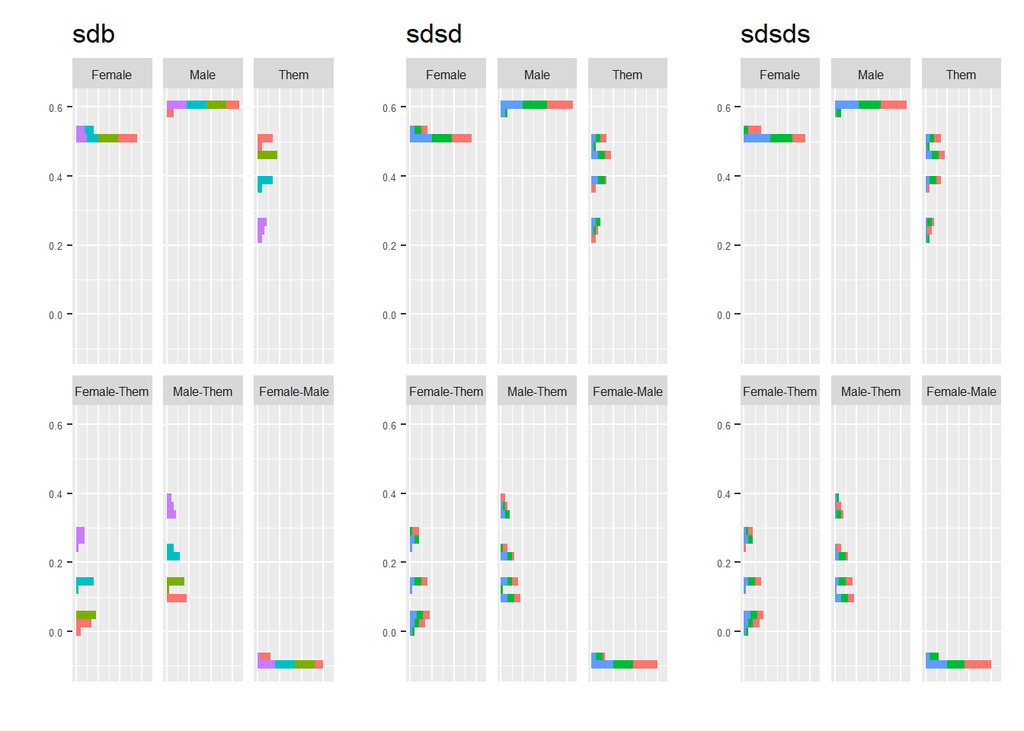

Parameter estimates (on y axis) for different priors

```r
Label_lvls = c("Female","Male","Them","Female-Them", "Male-Them", "Female-Male")
psa[, Label := factor(Label, levels =  Label_lvls)]

p = list(geom_histogram(bins = 30), facet_wrap(~Label) , coord_flip() ,
         theme(legend.position = "none", axis.text.x = element_blank(),
               axis.ticks.length.x = unit(0,"cm"),
               axis.text.y = element_text(size = 5),strip.text = element_text(size = 6)), xlab(""), ylab(""))

p1 = psa %>% ggplot(aes(x = M, fill = factor(sdb))) + p + ggtitle("sdb")
p2 = psa %>% ggplot(aes(x = M, fill = factor(sdsd))) + p + ggtitle("sdsd")
p3 = psa %>% ggplot(aes(x = M, fill = factor(sdsds))) + p + ggtitle("sdsds")

p1 | p2 | p3 + plot_layout(axis_titles = "collect")
```

We see that only increasing the variance for the fix effect priors makes a difference, and also here only for the small group with gender “Them”. We can verify this by only showing this part of the plot:

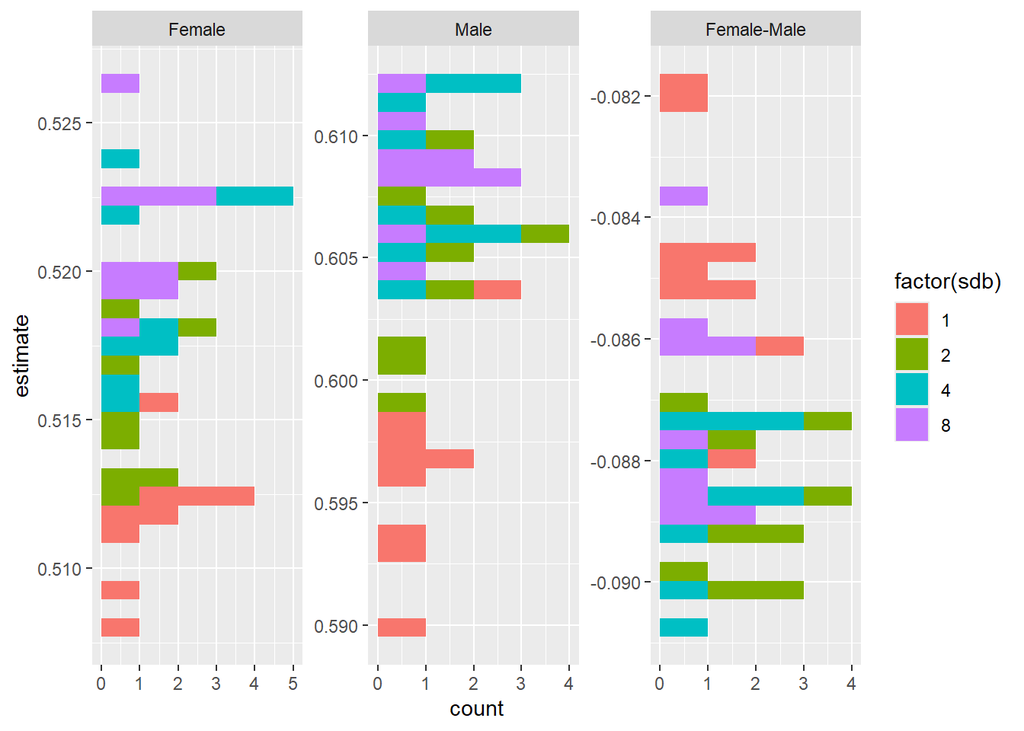

Parameter estimates (on y axis) for different priors for males and females only

```r
psa[!grepl("Them",Label)] %>%
  ggplot(aes(x = M, fill = factor(sdb))) +
  geom_histogram(bins = 30)+
  facet_wrap(~Label, scales = "free") +
  coord_flip() +
  xlab("estimate")
```

We see a very small effect of the chosen prior: Even though the priors with smaller standard deviation lead to a bit more shrinkage, this effect is small compared with the effect sizes. We can visualize this by not showing the estimated effects, but their relative deviation, i.e. the the distance from the mean devided by the mean.

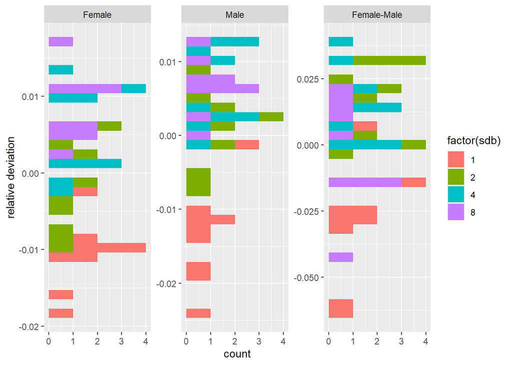

```r
psa[, RD := (M-mean(M))/mean(M), by = .(Label)]
psa[!grepl("Them",Label)] %>%
  ggplot(aes(x = RD, fill = factor(sdb))) +
  geom_histogram(bins = 30)+
  facet_wrap(~Label, scales = "free") +
  coord_flip() +
  xlab("relative deviation")
```

## Footnotes

[^1]: brms also has a `ranef` command that one can use to extract Fylke random effects parameters. However, it is not straight forward to use these when making predictions from a logistic regression model.